# E-Ladestationen der kantonalen Verwaltung Zürich

*von* *Samuel Belko,* *veröffentlicht am 8. Juni 2025.*

In diesem Dokument visualisiere ich öffentlich zugängliche Daten, die Ladevorgänge an E-Ladestationen der kantonalen Verwaltung Zürich zeigen. Weitere Informationen zu den Daten finden sich im Abschnitt Daten unten.

### Wo sind die Ladestationen und wie oft wurden sie benutzt?

Klicke auf einen Marker, um die Anzahl der Ladungen zwichen dem 01.10.2021 und dem 31.03.2025 an diesem Ort zu sehen. Drei Standorte mit fehlerhaften Adressangaben werden nicht angezeigt.

[interactive chart not shown]

### Was ist der Trend im Ladeverhalten über die letzten Jahre?

Bitte beachten Sie, dass die Daten im Zeitraum von 01.10.2021 bis zum 31.03.2025 erhoben wurden. Daher skalieren wir die Anzahl der Ladevorgänge sowie den gesamten Energieverbrauch für die Jahre 2021 und 2025 mit dem Faktor 4, um eine Vergleichbarkeit herzustellen. Die folgenden Diagramme zeigen den geschätzten Trend im Ladeverhalten über diesen Zeitraum.

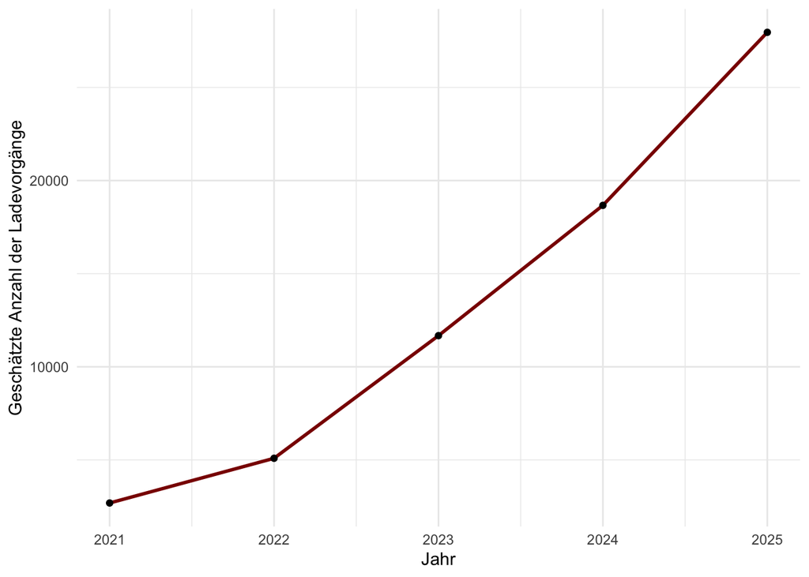

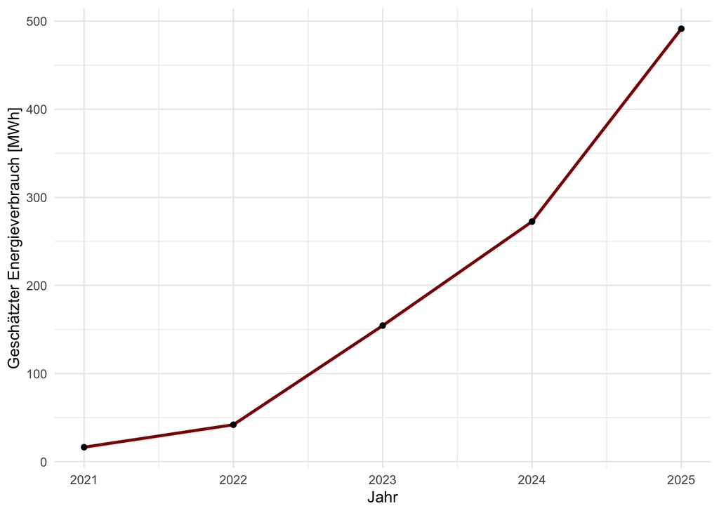

Der durschnittliche Energieverbrauch eines Haushalts mit drei oder mehr Personen beträgt etwa 5 MWh pro Jahr, wie das [Statistische Bundesamt](https://www.destatis.de/EN/Themes/Society-Environment/Environment/Environmental-Economic-Accounting/private-households/Tables/electricity-consumption-private-households.html) angibt. Damit lässt sich ein Vergleich herstellen, der geschätzte Energieverbrauch der Ladestationen im Jahr 2025 entspricht in etwa dem Hundertfachen eines solchen Haushalts.

### Daten

- Quelle: https://www.zh.ch/de/politik-staat/statistik-daten/datenkatalog.html#/datasets/2282@ima-kanton-zuerich/distributions/4563
- Zeitraum: 01.10.2021 - 31.03.2025
- Lizenz: CC-Zero: Creative Commons Public Domain Lizenz

Die Daten liegen in CSV-Format vor und die Datei enthält 43093 Zeilen. Hier sind die ersten 10 Zeilen der Daten:

id

jahr

stadt

plz

strasse

haus_nr

ladeleistung

connector_typ

stop_typ

aktiver_energieverbrauch

aktive_ladeleistung

charge_point_besitzer

vertrag_typ

18691178

2025

Urdorf

8902

Werkhofstrasse

5

20.01

Type 2 socket

EV getrennt

34.095

19.200

Kantonspolizei des Kantons Zürich

Plug’n Roll

18690578

2025

Urdorf

8902

Werkhofstrasse

5

20.01

Type 2 socket

EV getrennt

33.546

19.264

Kantonspolizei des Kantons Zürich

Plug’n Roll

18690156

2025

Urdorf

8902

Werkhofstrasse

5

20.01

Type 2 socket

EV getrennt

2.897

19.072

Kantonspolizei des Kantons Zürich

Plug’n Roll

18689899

2025

Hinwil

8340

Affeltrangerstrasse

6. Aug

20.01

Type 2 socket

EV getrennt

47.809

19.200

Kantonspolizei des Kantons Zürich

Plug’n Roll

18688283

2025

Regensdorf

8105

Untere Mühlestrasse

1

20.01

Type 2 socket

EV getrennt

36.042

19.520

Kantonspolizei des Kantons Zürich

Plug’n Roll

18687749

2025

Feuerthalen

8245

Zürcherstrasse

25

20.01

Type 2 socket

Lokaler Stop

10.300

3.328

Kantonspolizei des Kantons Zürich

Plug’n Roll

18687747

2025

Dübendorf

8600

Auenstrasse

4

20.01

Type 2 socket

EV getrennt

17.242

10.944

Kantonspolizei des Kantons Zürich

Plug’n Roll

18687447

2025

Thalwil

8800

Alte Landstrasse

153

20.01

Type 2 socket

EV getrennt

6.048

3.328

Kantonspolizei des Kantons Zürich

Plug’n Roll

18687421

2025

Andelfingen

8450

Thurtalstrasse

17

20.01

Type 2 socket

EV getrennt

2.313

3.328

Kantonspolizei des Kantons Zürich

Plug’n Roll

18686968

2025

Hinwil

8340

Affeltrangerstrasse

8

20.01

Type 2 socket

EV getrennt

58.899

10.816

Tiefbauamt Kanton Zürich

Plug’n Roll

Die Einheiten sind nicht angegeben. Ich gehen davon aus, dass der aktive Energieverbrauch in [kWh] angegeben ist.

### Code

Der Code is verfügbar unter https://github.com/samuelbelko/evchargezurich.